# Reproducible Data Analysis Project

## Introduction

Basketball is a popular team sport where two teams, each consisting of five players on the court, compete against each other by shooting a ball through a hoop to score points. The objective of the game is to score more points than the opposing team within a fixed time frame. Key metrics and position requirements in basketball are essential in evaluating player performance and building a successful team.

#### Relevant background information of basketball, including key metrics, position requirements etc:

In basketball, players are categorized into five positions, each with unique roles and responsibilities: point guard (PG), shooting guard (SG), small forward (SF), power forward (PF), and center (C). Key performance metrics include points, rebounds, assists, steals, blocks, and turnovers, which help evaluate a player’s overall effectiveness on the court. Advanced metrics like Player Efficiency Rating (PER) and Win Shares (WS) provide more comprehensive evaluations of a player’s contributions to the team’s success.

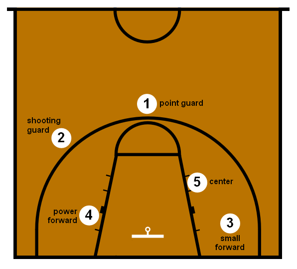

[1]

### Description of the scenario:

The general manager of a professional basketball team is looking to build a competitive roster while staying within the salary cap limitations. The team needs to find the best starting five players within their budget, taking into account player performance metrics, positions, and salary demands. [2]

## The aim of the project:

The primary goal of this project is to analyze basketball player performance data, including advanced metrics, positions, and salaries, to provide data-driven recommendations for selecting the optimal starting five players within the team’s budget constraints.

## Justification and importance:

By leveraging data analysis and modeling techniques, this project can help the team make informed decisions on player acquisitions, ensuring the best possible roster composition while staying within the salary cap. This approach not only improves the team’s competitiveness on the court but also ensures financial sustainability in a highly competitive professional sports environment. Furthermore, the insights gained from this analysis can be used by other teams to make more informed decisions when building their rosters.

## Reading and cleaning the raw data

### NBA Player Salaries

| player_id | player_name | salary |
| --- | --- | --- |
| 1 | Alex Abrines | 3667645 |
| 2 | Quincy Acy | 213948 |
| 3 | Steven Adams | 24157304 |
| 4 | Jaylen Adams | 236854 |
| 5 | Bam Adebayo | 2955840 |
| 6 | Deng Adel | 77250 |

The above dataset has 3 columns, Id of the player, name and the salary of the player. Lets check for NA values

### NBA Player Statistics

| player_name | Pos | Age | Tm | G | GS | MP | FG | FGA | FG% | 3P | 3PA | 3P% | 2P | 2PA | 2P% | eFG% | FT | FTA | FT% | ORB | DRB | TRB | AST | STL | BLK | TOV | PF | PTS |
| --- | --- | --- | --- | --- | --- | --- | --- | --- | --- | --- | --- | --- | --- | --- | --- | --- | --- | --- | --- | --- | --- | --- | --- | --- | --- | --- | --- | --- |
| Alex Abrines | SG | 25 | OKC | 31 | 2 | 588 | 56 | 157 | 0.357 | 41 | 127 | 0.323 | 15 | 30 | 0.500 | 0.487 | 12 | 13 | 0.923 | 5 | 43 | 48 | 20 | 17 | 6 | 14 | 53 | 165 |
| Quincy Acy | PF | 28 | PHO | 10 | 0 | 123 | 4 | 18 | 0.222 | 2 | 15 | 0.133 | 2 | 3 | 0.667 | 0.278 | 7 | 10 | 0.700 | 3 | 22 | 25 | 8 | 1 | 4 | 4 | 24 | 17 |
| Jaylen Adams | PG | 22 | ATL | 34 | 1 | 428 | 38 | 110 | 0.345 | 25 | 74 | 0.338 | 13 | 36 | 0.361 | 0.459 | 7 | 9 | 0.778 | 11 | 49 | 60 | 65 | 14 | 5 | 28 | 45 | 108 |
| Steven Adams | C | 25 | OKC | 80 | 80 | 2669 | 481 | 809 | 0.595 | 0 | 2 | 0.000 | 481 | 807 | 0.596 | 0.595 | 146 | 292 | 0.500 | 391 | 369 | 760 | 124 | 117 | 76 | 135 | 204 | 1108 |
| Bam Adebayo | C | 21 | MIA | 82 | 28 | 1913 | 280 | 486 | 0.576 | 3 | 15 | 0.200 | 277 | 471 | 0.588 | 0.579 | 166 | 226 | 0.735 | 165 | 432 | 597 | 184 | 71 | 65 | 121 | 203 | 729 |
| Deng Adel | SF | 21 | CLE | 19 | 3 | 194 | 11 | 36 | 0.306 | 6 | 23 | 0.261 | 5 | 13 | 0.385 | 0.389 | 4 | 4 | 1.000 | 3 | 16 | 19 | 5 | 1 | 4 | 6 | 13 | 32 |

The above dataset shows the statistics of each player.

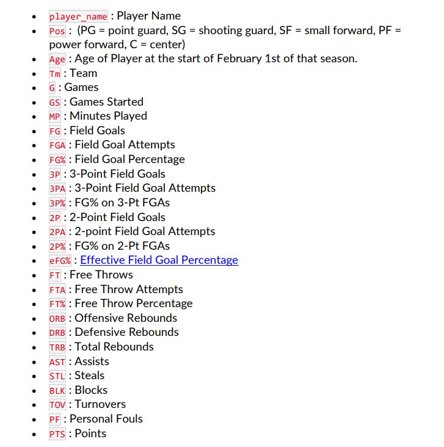

### NBA Team Statistics 1

| Rk | Team | Age | W | L | PW | PL | MOV | SOS | SRS | ORtg | DRtg | NRtg | Pace | FTr | 3PAr | TS% | eFG% | TOV% | ORB% | FT/FGA | DRB% | ...23 | ...24 | ...25 |
| --- | --- | --- | --- | --- | --- | --- | --- | --- | --- | --- | --- | --- | --- | --- | --- | --- | --- | --- | --- | --- | --- | --- | --- | --- |
| 1 | Milwaukee Bucks | 26.9 | 60 | 22 | 61 | 21 | 8.87 | -0.82 | 8.04 | 113.8 | 105.2 | 8.6 | 103.3 | 0.255 | 0.419 | 0.583 | 0.550 | 12.0 | 20.8 | 0.197 | 80.3 | NA | NA | NA |
| 2 | Golden State Warriors | 28.4 | 57 | 25 | 56 | 26 | 6.46 | -0.04 | 6.42 | 115.9 | 109.5 | 6.4 | 100.9 | 0.227 | 0.384 | 0.596 | 0.565 | 12.6 | 22.5 | 0.182 | 77.1 | NA | NA | NA |
| 3 | Toronto Raptors | 27.3 | 58 | 24 | 56 | 26 | 6.09 | -0.60 | 5.49 | 113.1 | 107.1 | 6.0 | 100.2 | 0.247 | 0.379 | 0.579 | 0.543 | 12.4 | 21.9 | 0.198 | 77.1 | NA | NA | NA |
| 4 | Utah Jazz | 27.3 | 50 | 32 | 54 | 28 | 5.26 | 0.03 | 5.28 | 110.9 | 105.7 | 5.2 | 100.3 | 0.295 | 0.394 | 0.572 | 0.538 | 13.4 | 22.9 | 0.217 | 80.3 | NA | NA | NA |
| 5 | Houston Rockets | 29.2 | 53 | 29 | 53 | 29 | 4.77 | 0.19 | 4.96 | 115.5 | 110.7 | 4.8 | 97.9 | 0.279 | 0.519 | 0.581 | 0.542 | 12.0 | 22.8 | 0.221 | 74.4 | NA | NA | NA |
| 6 | Portland Trail Blazers | 26.2 | 53 | 29 | 51 | 31 | 4.20 | 0.24 | 4.43 | 114.7 | 110.5 | 4.2 | 99.1 | 0.258 | 0.339 | 0.568 | 0.528 | 12.1 | 26.6 | 0.210 | 77.9 | NA | NA | NA |

### NBA Team Statistics 2

| Rk | Team | G | MP | FG | FGA | FG% | 3P | 3PA | 3P% | 2P | 2PA | 2P% | FT | FTA | FT% | ORB | DRB | TRB | AST | STL | BLK | TOV | PF | PTS |
| --- | --- | --- | --- | --- | --- | --- | --- | --- | --- | --- | --- | --- | --- | --- | --- | --- | --- | --- | --- | --- | --- | --- | --- | --- |
| 1 | Milwaukee Bucks | 82 | 19780 | 3555 | 7471 | 0.476 | 1105 | 3134 | 0.353 | 2450 | 4337 | 0.565 | 1471 | 1904 | 0.773 | 762 | 3316 | 4078 | 2136 | 615 | 486 | 1137 | 1608 | 9686 |
| 2 | Golden State Warriors | 82 | 19805 | 3612 | 7361 | 0.491 | 1087 | 2824 | 0.385 | 2525 | 4537 | 0.557 | 1339 | 1672 | 0.801 | 797 | 2990 | 3787 | 2413 | 625 | 525 | 1169 | 1757 | 9650 |
| 3 | New Orleans Pelicans | 82 | 19755 | 3581 | 7563 | 0.473 | 842 | 2449 | 0.344 | 2739 | 5114 | 0.536 | 1462 | 1921 | 0.761 | 909 | 2969 | 3878 | 2216 | 610 | 441 | 1215 | 1732 | 9466 |
| 4 | Philadelphia 76ers | 82 | 19805 | 3407 | 7233 | 0.471 | 889 | 2474 | 0.359 | 2518 | 4759 | 0.529 | 1742 | 2258 | 0.771 | 892 | 3025 | 3917 | 2207 | 606 | 432 | 1223 | 1745 | 9445 |
| 5 | Los Angeles Clippers | 82 | 19830 | 3384 | 7178 | 0.471 | 821 | 2118 | 0.388 | 2563 | 5060 | 0.507 | 1853 | 2340 | 0.792 | 796 | 2936 | 3732 | 1970 | 561 | 385 | 1193 | 1913 | 9442 |
| 6 | Portland Trail Blazers | 82 | 19855 | 3470 | 7427 | 0.467 | 904 | 2520 | 0.359 | 2566 | 4907 | 0.523 | 1558 | 1914 | 0.814 | 967 | 2968 | 3935 | 1887 | 546 | 413 | 1135 | 1669 | 9402 |

The above dataset shows the statistics of Teams.

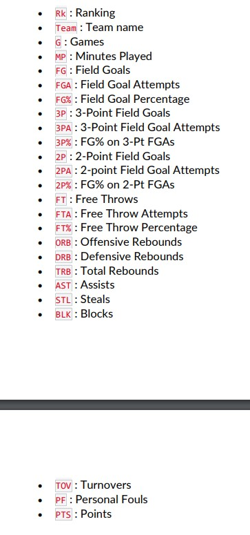

Fig.Team Statistics.

|  | team_id | team | salary |
| --- | --- | --- | --- |
| 1 | 1 | Miami | $153,171,497 |
| 2 | 2 | Golden State | $146,291,276 |
| 3 | 3 | Oklahoma City | $144,916,427 |
| 4 | 4 | Toronto | $137,793,831 |
| 5 | 5 | Milwaukee | $130,988,604 |
| 6 | 6 | Portland | $130,256,600 |

The above dataset shows Team Payroll or the budget for the next season

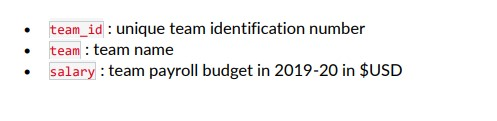

[output not shown]

There are 0 NA values in this dataset NBA player salaries.

## Exploratory analysis

### A) Checking for errors and missing values within the datasets

```
## Number of NA values in the dataframe: 0
```

```
## Number of NA values in the dataframe: 0
```

```
## Number of NA values in the dataframe: 117
```

```
## Number of NA values in the dataframe: 90
```

```
## Number of NA values in the dataframe: 0
```

1. Zero NA valuesin team_payroll and player salaries.
2. We have replace 117 NA values of team_stats_1 data to 0.
3. We have replace 90 NA values of team_stats_1 data to 0.
4. There are no NA values in team_stats_2.

### B and C : Checking the distribution of variables & checking for relationships between variables, or differences between groups

1. Distribution of player salaries

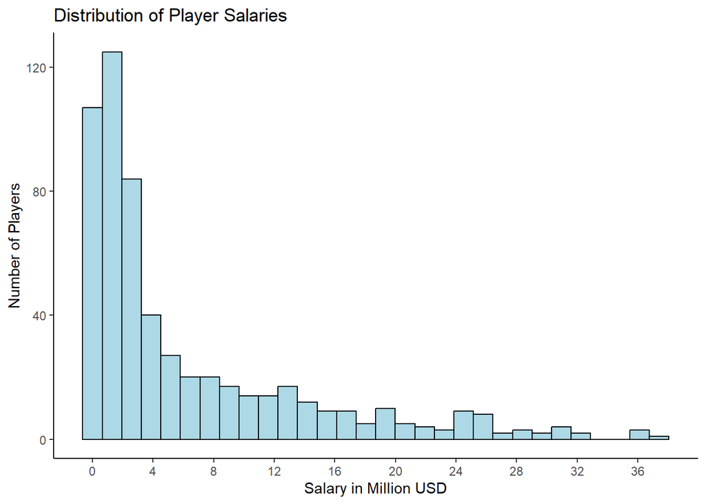

Salaries of the players are is distributed in the positively skewed manner

2. Top 15 players by points scored

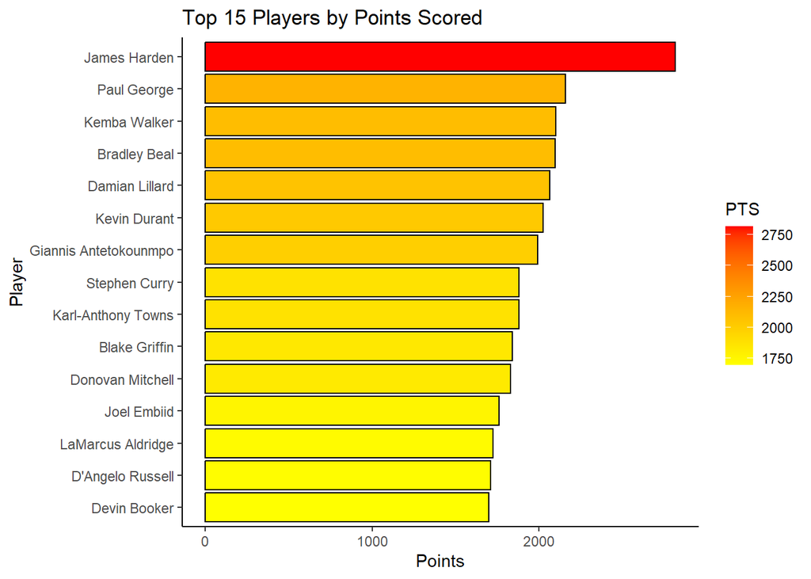

James Harden, Paul George, Kemba Walker. are the most point scored players. Also, We may have a probable outlier James Harden, since points scored is way off the charts compared to other top players.

3. Player positions distribution

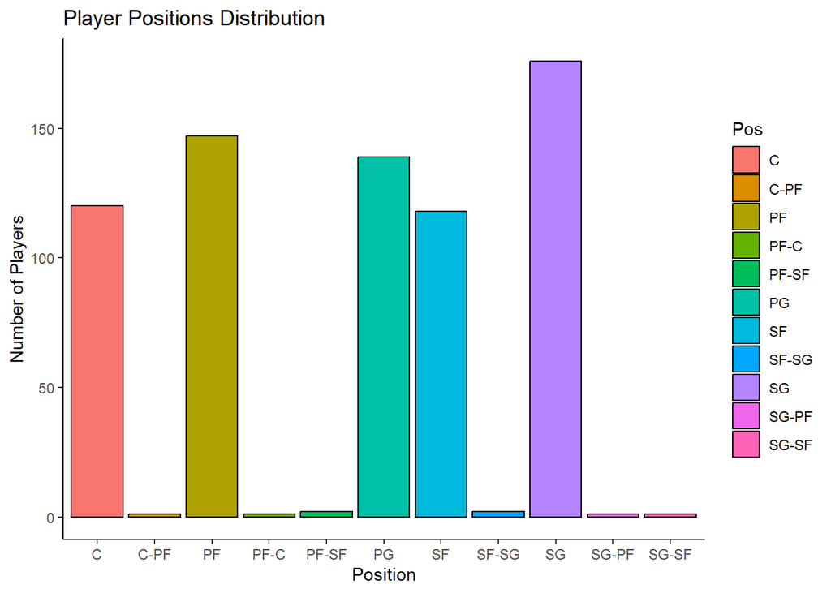

Player positions distribution.

4. Scatterplot of points vs. player efficiency rating

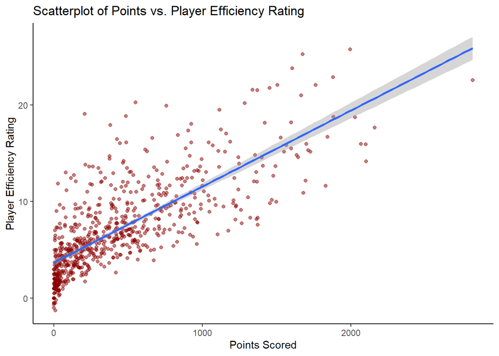

Efficiency Rating is directly proportional to the points scored by the players.

5. Player efficiency rating vs. salary

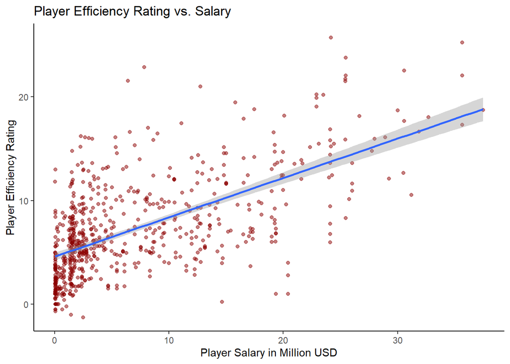

Efficiency Rating is directly proportional to the salaries of the players.

6. Top 15 most efficient players within budget

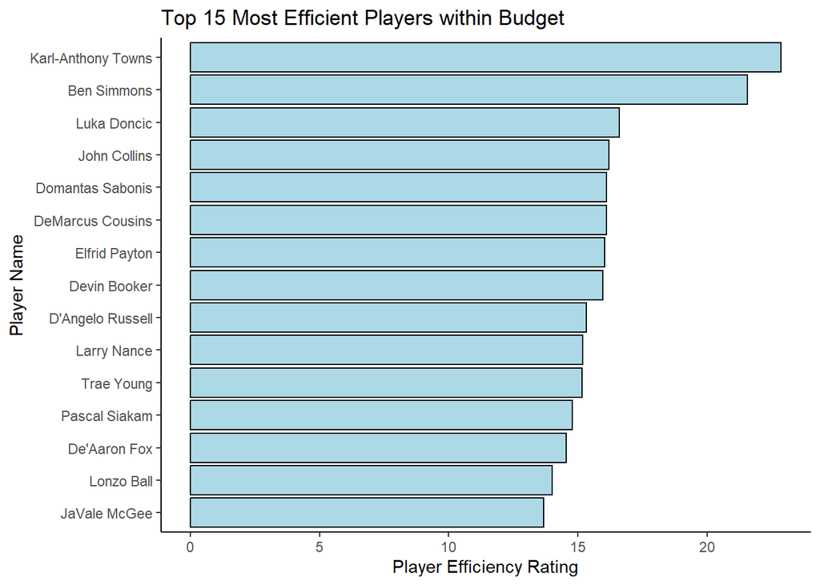

The bar graph shows the efficient players within the budget.

7. Top players by position within budget

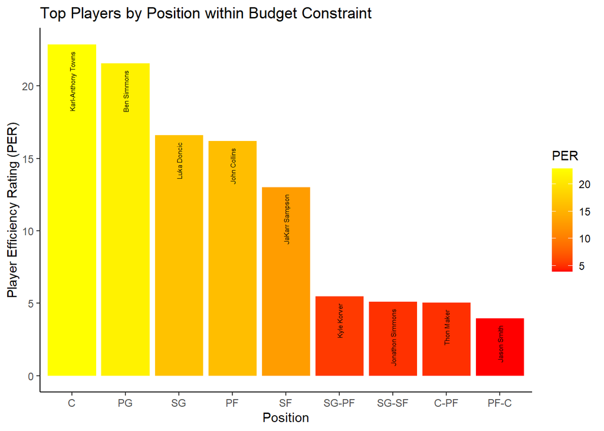

The graph is sorted as per player efficiency rating that shows which player can be the best for their specific poisiton based on the budget and the salaries Karl-Anthony, Thon Maker, Jogn Collins, Jason Smith, Ben Simmons, Jakarr Sampson, Luke Doncic, Kyle Korver, Jonathon Simmons.

8. Boxplot of player efficiency rating by position

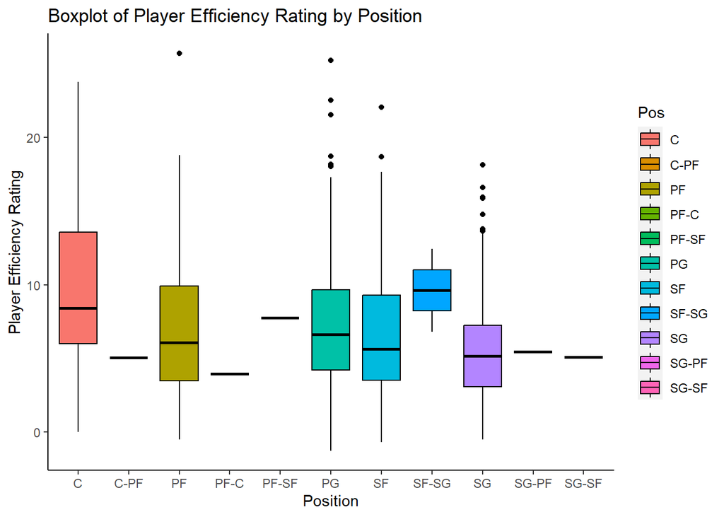

The above Boxplot proves our previous assumption about outliers, hence we can remove those outliers and move on to further analysis.

9. Scatterplot of player age vs. player efficiency rating

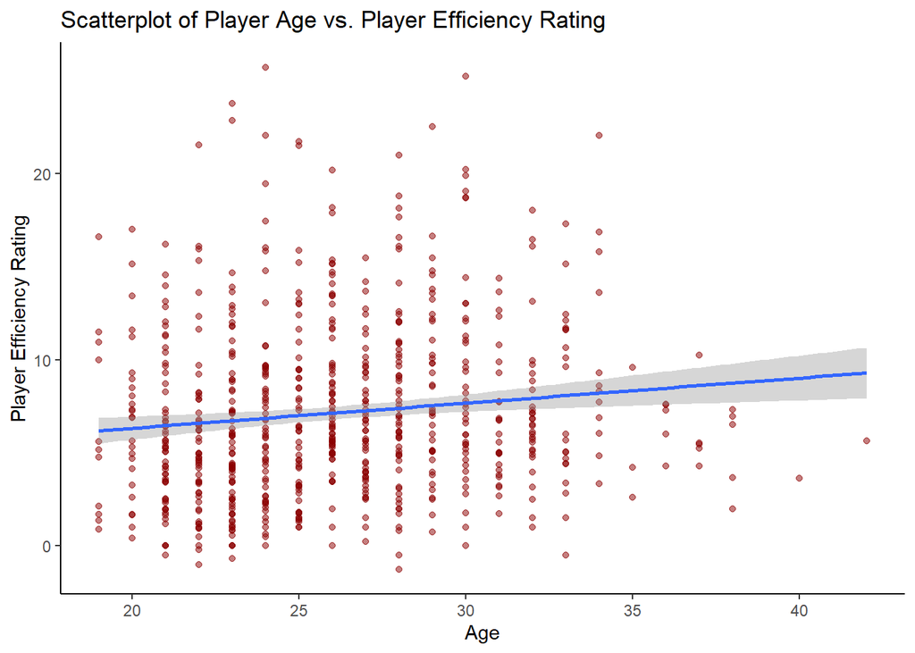

10. Average Player Efficiency Rating by Team

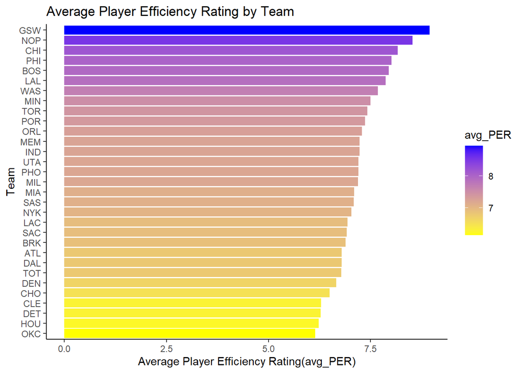

10.1 Average Player Efficiency Rating by Team in comparison with Salaries

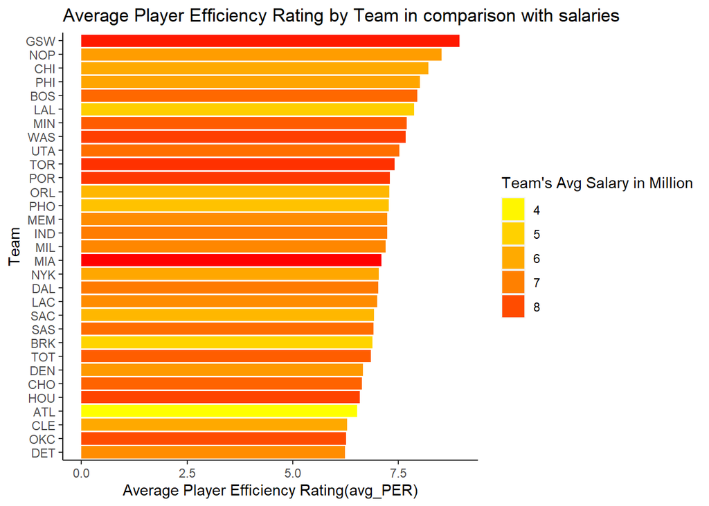

In the above plot, we can observe that most efficient players in team is not cost effective. Even so, we can’t consider least expensive players, they doesn’t seem to be efficient. Finding the sweet spot in the middle is our moto with the help of this project.

11. Scatterplot of games played vs. player efficiency rating

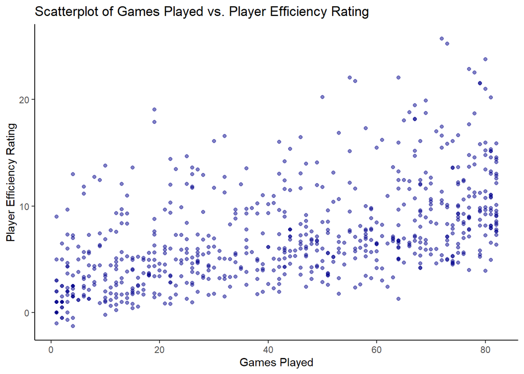

12. Plotting relationship between the Field goals and Points

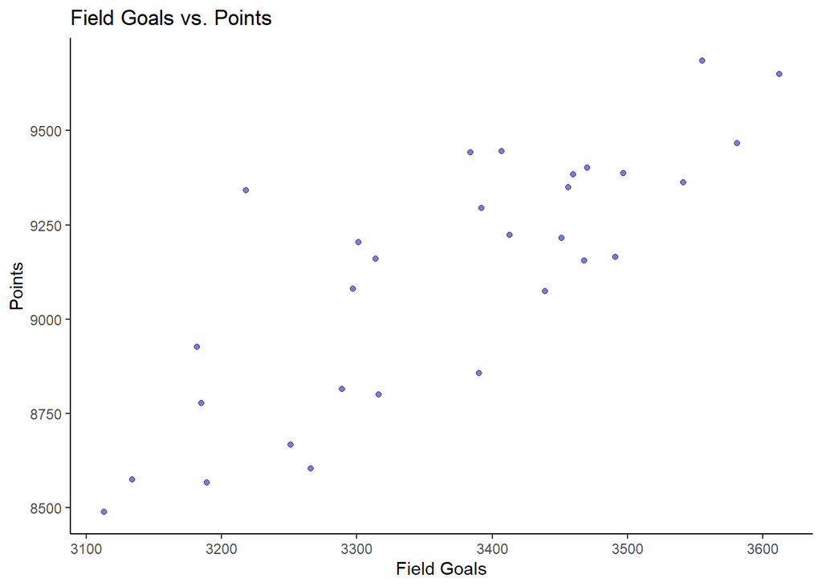

It shows the positive correlation between these two varaibles2

13. Plotting relationship between the 3point field Goals and Points

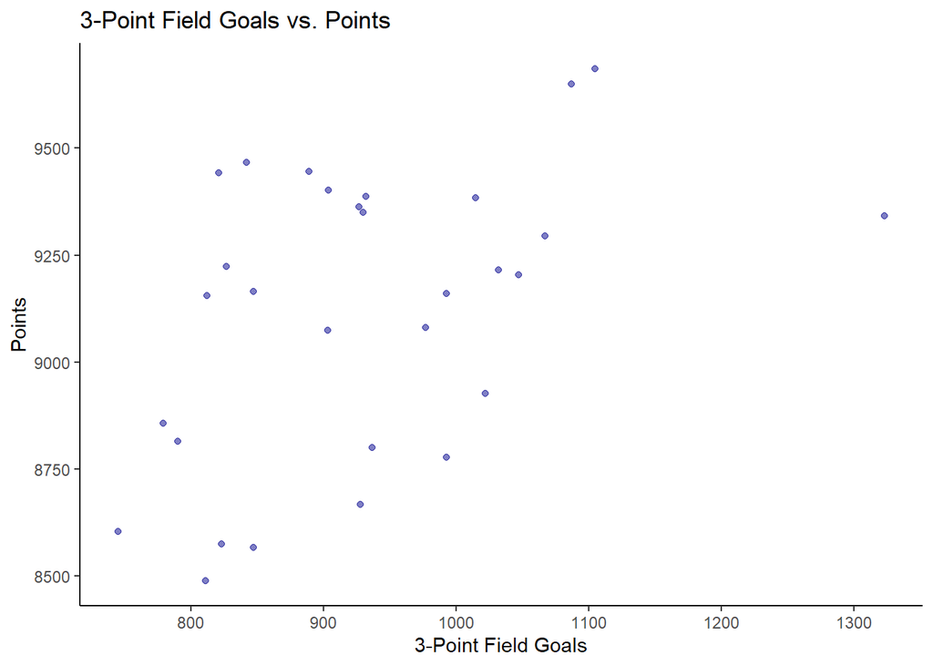

It shows the positive correlation between these two varaibles

14. Plotting relationship between the 2point field Goals and Points

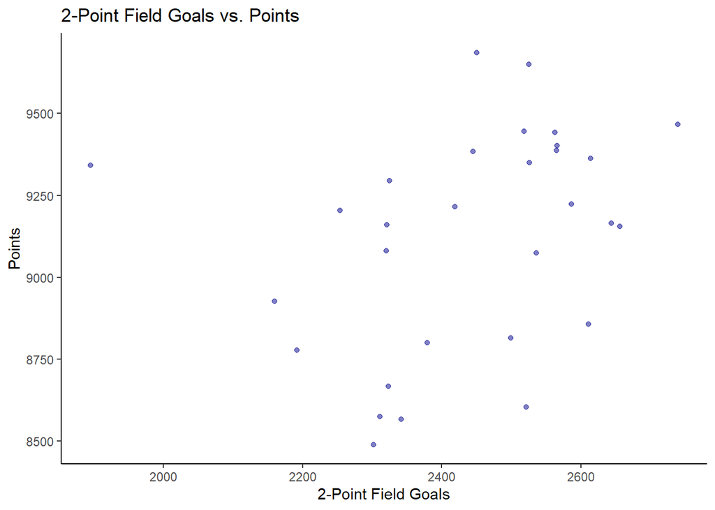

It shows the somewhat neutral relationship between the varaibles

15. Plotting relationship between the : Effective Field Goal Percentage and Points

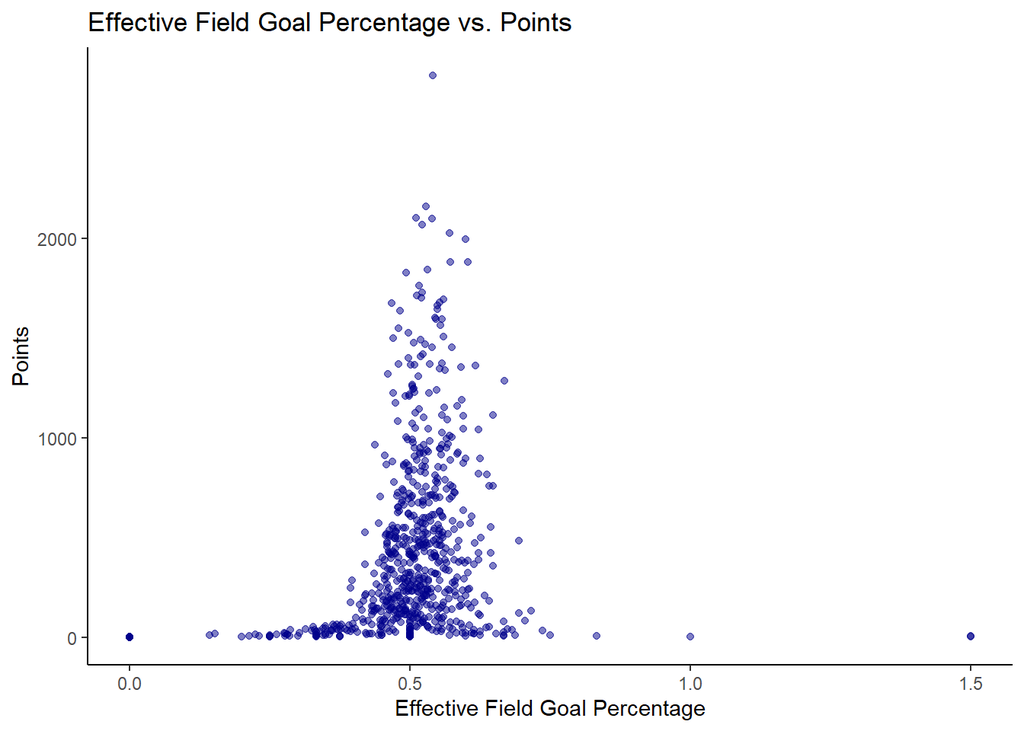

Correlation Matrix of the analysed variables.

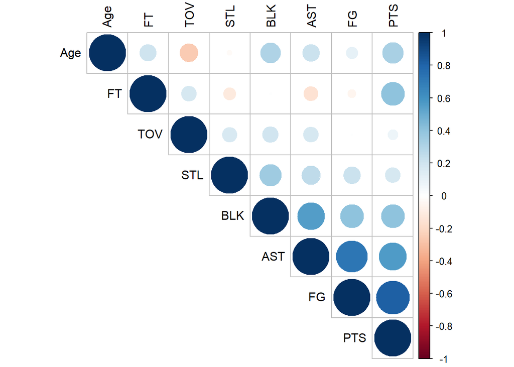

We began by cleaning and preprocessing the data to ensure its integrity and reliability. This included handling missing values, eliminating outliers, and merging the datasets to create a comprehensive source of information.

Next, we conducted an exploratory data analysis to understand the distributions of various metrics, identify relationships between variables, and detect any potential issues or biases. We examined factors such as player performance, age, and salary, and used visualizations to gain insights into the data.

Based on our findings, we have recommended a starting lineup that not only meets the budget constraints but also offers a balanced and strong team composition. We have considered the strengths and weaknesses of each player, their respective positions, and their performance statistics to make an informed decision.

## Data modelling and results

### Data modelling (e.g. creating a linear regression)

```
##
## Call:
## lm(formula = PER ~ ., data = player_stats_salaries[, features])
##
## Residuals:
##     Min      1Q  Median      3Q     Max
## -4.8513 -1.3053 -0.3348  0.8150  9.4946
##
## Coefficients:
##               Estimate Std. Error t value Pr(>|t|)
## (Intercept)  3.069e+00  1.411e-01  21.749  < 2e-16 ***
## MP          -2.035e-03  4.508e-04  -4.514 7.50e-06 ***
## PTS          6.699e-04  6.828e-04   0.981   0.3269
## TRB          1.426e-02  1.071e-03  13.313  < 2e-16 ***
## AST          1.322e-02  2.021e-03   6.539 1.22e-10 ***
## STL          9.899e-03  6.151e-03   1.609   0.1080
## BLK          1.373e-02  5.263e-03   2.608   0.0093 **
## TOV          8.898e-03  6.003e-03   1.482   0.1387
## PF           5.412e-04  3.788e-03   0.143   0.8864
## salary       1.258e-07  1.288e-08   9.767  < 2e-16 ***
## ---
## Signif. codes:  0 '***' 0.001 '**' 0.01 '*' 0.05 '.' 0.1 ' ' 1
##
## Residual standard error: 2.107 on 676 degrees of freedom
## Multiple R-squared:  0.805,  Adjusted R-squared:  0.8024
## F-statistic: 310.1 on 9 and 676 DF,  p-value: < 2.2e-16
```

We created a linear regression model to predict a player’s efficiency rating (PER) using relevant features such as minutes played, points, total rebounds, assists, steals, blocks, turnovers, personal fouls, and salary.

We interpreted the model output by looking at the coefficients and their significance. This helps us understand the impact of each feature on a player’s efficiency rating.[13]

### Linearity of the data

The linearity assumption[12] can be checked by inspecting the Residuals vs Fitted plot (1st plot):

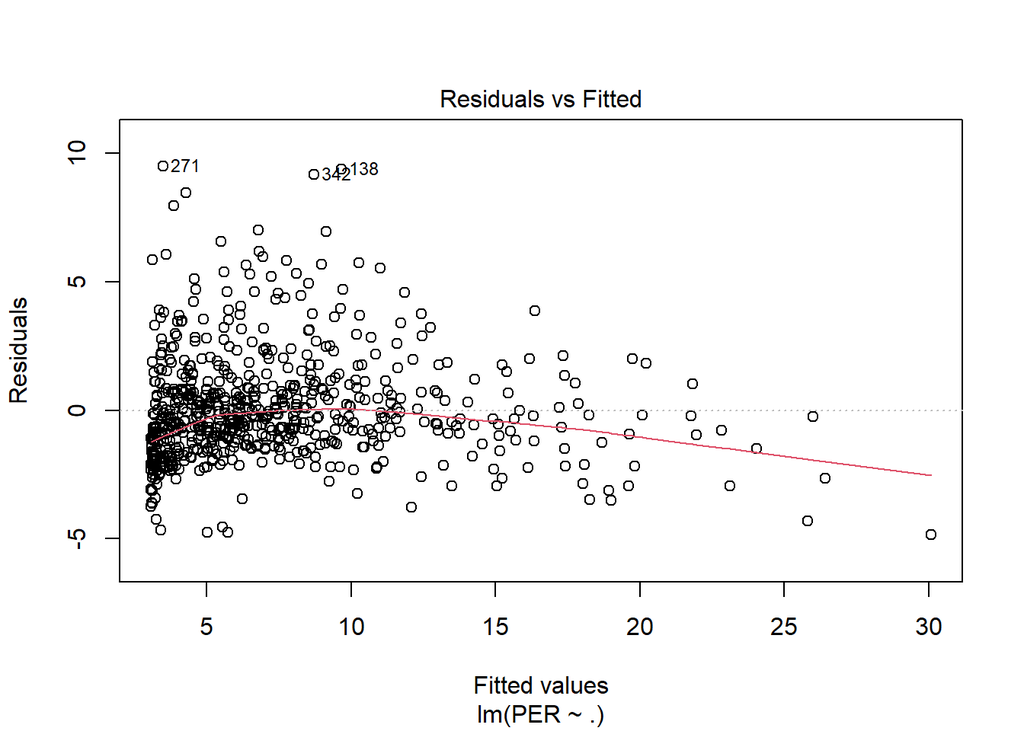

### Homogeneity of variance

This assumption[12] can be checked by examining the scale-location plot, also known as the spread-location plot.

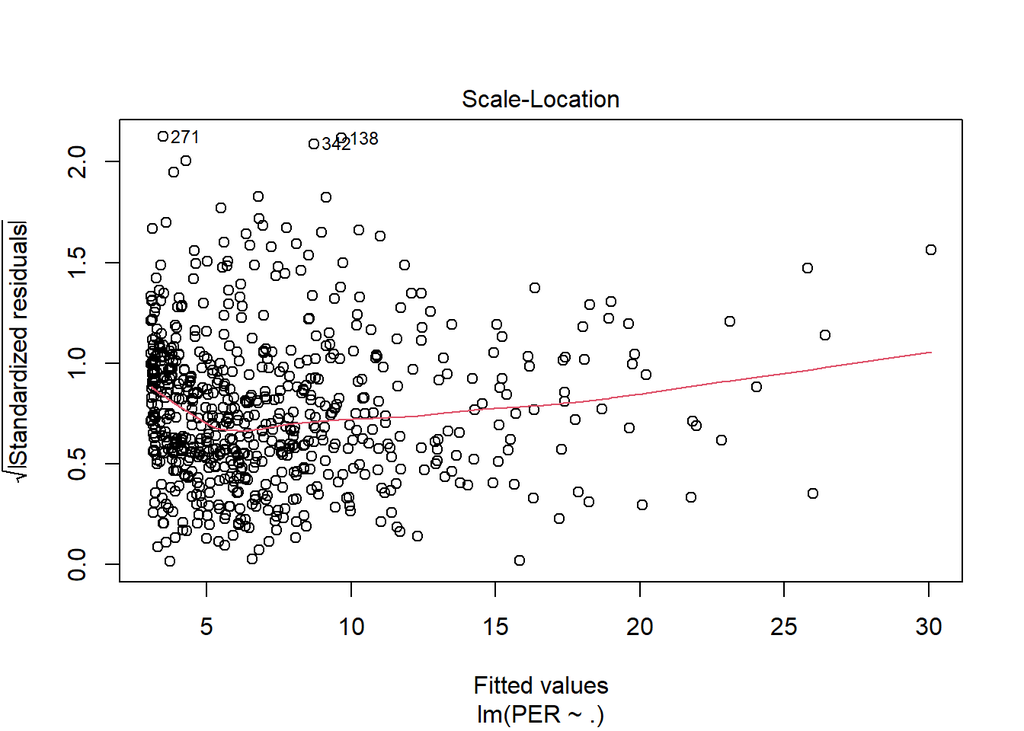

This plot shows if residuals are spread equally along the ranges of predictors. It’s good if you see a horizontal line with equally spread points.

### Normality of residuals

The QQ plot of residuals[12] can be used to visually check the normality assumption. The normal probability plot of residuals should approximately follow a straight line.

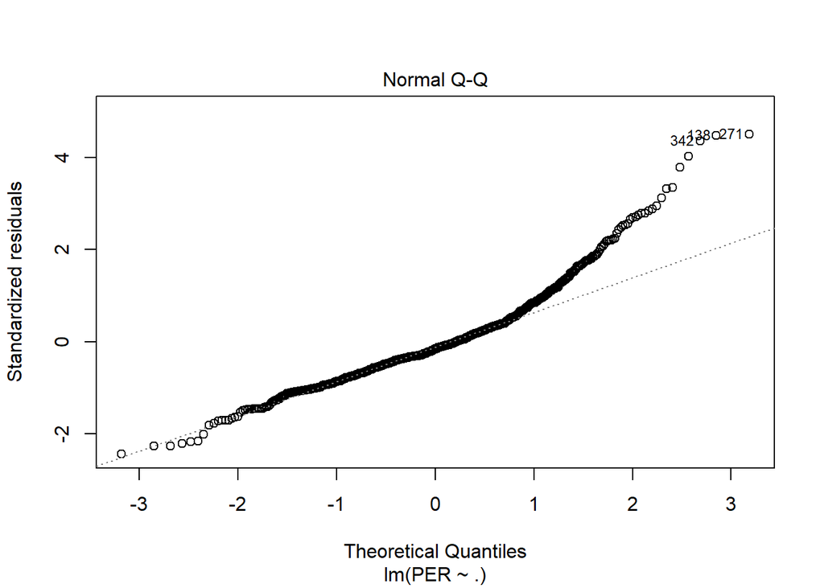

### Influential values

The following plots illustrate the Cook’s distance and the leverage of our model[12]:

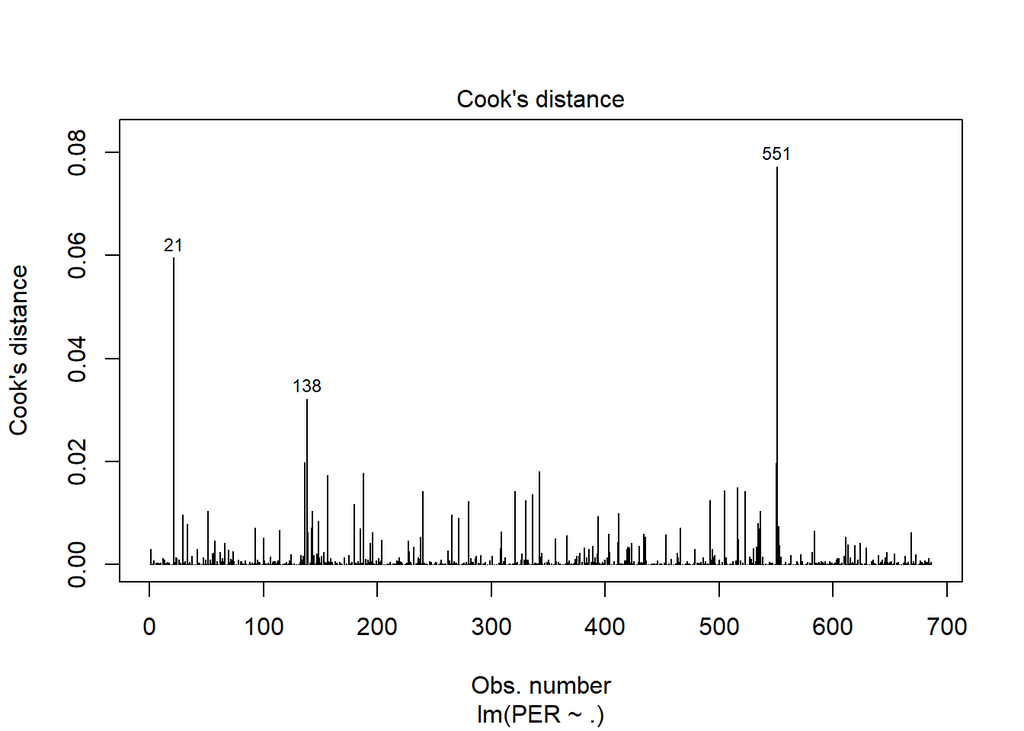

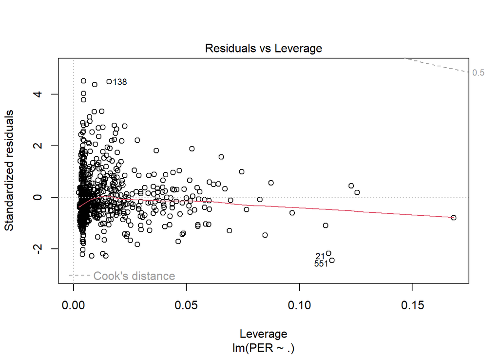

### Model output and interpretation of Linear model

Here we can see some variables significant while some are insignificant variables. Significant of variables can be decided by the p value. If p value is less than 0.05 then we reject the null hypothesis and that where we accept the alternative hypothesis which is “h0 not equal to 0”.

## Player recommendations

For presenting the best five starting players to the general manager, we can create a table with the relevant information such as player name, position, predicted PER, salary, and key statistics (e.g., points, rebounds, assists). Additionally, we can highlight other factors that may impact their performance or team dynamics, such as recent injuries, team fit, and individual performance trends.

```
## # A tibble: 19 × 11
## # Groups:   Pos [9]
##    player_name    Pos   predicted_PER salary   PTS   TRB   AST   STL   BLK   TOV
##    <chr>          <chr>         <dbl>  <dbl> <dbl> <dbl> <dbl> <dbl> <dbl> <dbl>
##  1 Domantas Sabo… C             15.4  2.66e6  1043   690   212    48    30   160
##  2 Karl-Anthony … C             21.8  7.84e6  1880   954   259    67   125   240
##  3 Willie Cauley… C             14.6  4.70e6   965   678   194    96    51    84
##  4 Thon Maker     C-PF           6.39 2.80e6   323   202    45    21    51    33
##  5 Al-Farouq Ami… PF            11.7  6.96e6   760   610   104    68    33    72
##  6 John Collins   PF            12.4  2.30e6  1188   595   121    22    39   120
##  7 Pascal Siakam  PF            13.0  1.54e6  1354   549   248    73    52   154
##  8 Jason Smith    PF-C           4.60 5.45e6    65    52    14     3     7    13
##  9 Ben Simmons    PG            21.8  6.43e6  1337   697   610   112    61   274
## 10 De'Aaron Fox   PG            15.7  5.47e6  1399   304   590   133    45   227
## 11 Trae Young     PG            16.3  5.36e6  1549   301   653    72    15   308
## 12 Jae Crowder    SF             9.36 7.31e6   951   384   133    64    31    85
## 13 Jayson Tatum   SF            11.6  6.70e6  1243   477   168    84    57   122
## 14 Justise Winsl… SF            11.2  3.45e6   830   355   282    72    19   142
## 15 Devin Booker   SG            12.8  3.31e6  1700   265   433    56    13   264
## 16 Donovan Mitch… SG            11.7  3.11e6  1829   316   322   106    31   218
## 17 Luka Doncic    SG            17.3  6.57e6  1526   563   429    77    25   247
## 18 Kyle Korver    SG-PF          6.08 7.56e6   600   162    81    25    12    59
## 19 Jonathon Simm… SG-SF          6.54 6   e6   366   126   128    29    15    68
## # ℹ 1 more variable: PF <dbl>
```

To further enhance the presentation of this information, you can create visualizations such as bar charts [7] for comparing the recommended players’ key statistics and a scatter plot[7] to show the relationship between their salary and predicted PER. This will provide the general manager with an easy-to-understand visual representation of the recommended players’ performance and value for money.

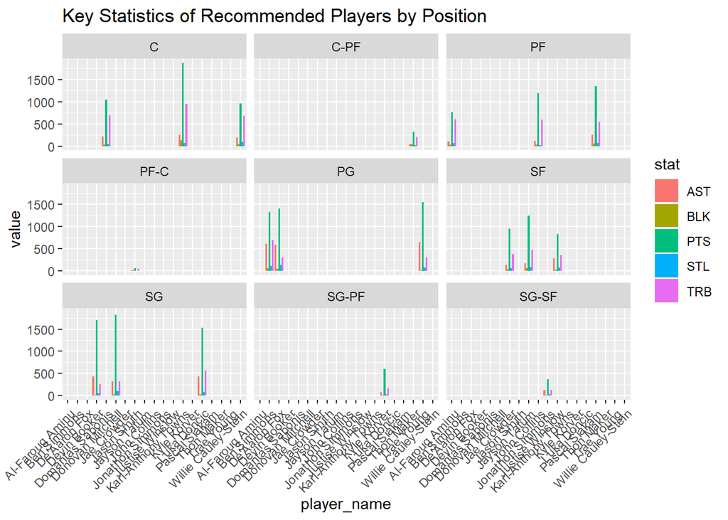

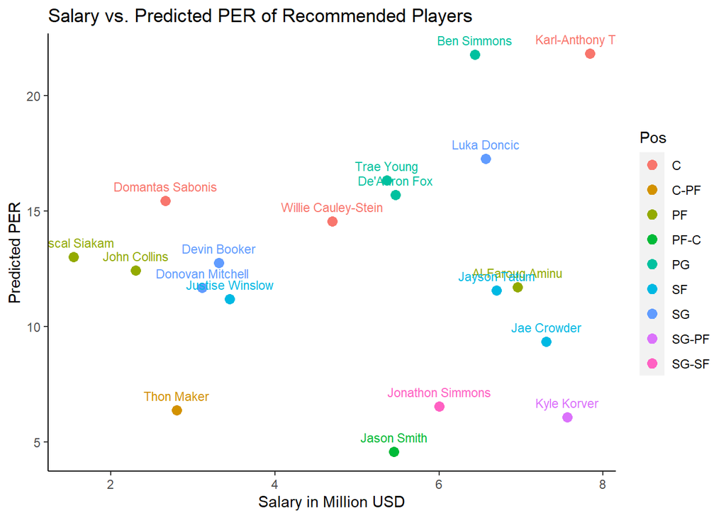

### Recommended Players for each Positions are

- Shooting Guard -> Luka Doncic
- Power Forward -> Pascal Siakam
- Point Guard -> Ben Simmons
- Center -> Karl-Anthony Towns
- Small Forward -> Jayson Tatum

  The Budget of the Chicago Bull for the next season is 118 Million. So total cost of these five players is $29088746. Therefore we are left with $88911254.

## Reference List [14]

[1] Wikipedia. Basketball positions [Internet]. [cited 2023 May 6]. Available from: https://en.wikipedia.org/wiki/Basketball_positions

[2] Rafael Irizarry. Case study: Moneyball [Internet]. Data Science for Biologists; [cited 2023 May 6]. Available from: https://rafalab.github.io/dsbook/linear-models.html#case-study-moneyball

[3] R-bloggers. NBA Analytics Tutorial: Using R to Display Player Career Stats [Internet]. [cited 2023 May 6]. Available from: https://www.r-bloggers.com/2021/12/nba-analytics-tutorial-using-r-to-display-player-career-stats/

[4] R-bloggers. ggplot2 transparent background quick guide [Internet]. [cited 2023 May 6]. Available from: https://www.r-bloggers.com/2022/07/ggplot2-transparent-background-quick-guide/

[5] Stack Overflow. ggplot histogram color gradient [Internet]. [cited 2023 May 6]. Available from: https://stackoverflow.com/questions/55446192/ggplot-histogram-color-gradient

[6] STHDA. ggplot2 colors: how to change colors automatically and manually [Internet]. [cited 2023 May 6]. Available from: http://www.sthda.com/english/wiki/ggplot2-colors-how-to-change-colors-automatically-and-manually

[7] Towards Data Science. Hands-on Guidance of Data Visualization in R Package ggplot2 of NBA Players Stats [Internet]. [cited 2023 May 6]. Available from: https://towardsdatascience.com/hands-on-guidance-of-data-visualization-in-r-package-ggplot2-of-nba-players-stats-d812ed272d66

[8] ggplot2. Documentation. [Internet]. [cited 2023 May 6]. Available from: https://ggplot2.tidyverse.org/

[9] RStudio. ggplot2 Essentials for Great Data Visualization in R [Internet]. RStudio; 2022 [cited 2023 May 6]. Available from: https://rstudio-pubs-static.s3.amazonaws.com/659632_2dd8c61a027d4fd0a34de4a6c6cec048.html

[10] STHDA. ggplot2 barplots: quick start guide - R software and data visualization [Internet]. [cited 2023 May 6]. Available from: http://www.sthda.com/english/wiki/ggplot2-barplots-quick-start-guide-r-software-and-data-visualization.

[11] DataCamp. Linear Regression in R [Internet]. [cited 2023 May 6]. Available from: https://www.datacamp.com/tutorial/linear-regression-R

[12] Boston University School of Public Health. Correlation and Regression [Internet]. [cited 2023 May 6]. Available from: https://sphweb.bumc.bu.edu/otlt/MPH-Modules/BS/R/R5_Correlation-Regression/R5_Correlation-Regression4.html

[13] Analytics Vidhya. Deeper Regression Analysis: Insights and Diagnostics [Internet]. [cited 2023 May 6]. Available from: https://www.analyticsvidhya.com/blog/2016/07/deeper-regression-analysis-assumptions-plots-solutions/

[14] Canberra Institute of Technology Library. Vancouver Referencing Guide [Internet]. Canberra Institute of Technology; [updated 2021 Aug 18; cited 2023 May 6]. Available from: https://canberra.libguides.com/c.php?g=599301&p=4149536